# Titanicly

8/13/2018

## The Titanic

On April 15, 1912, disaster struck when the RMS Titanic collided with an iceberg in the North Atlantic, and over 1500 of her 2200 pasesengers perished.

[figure not shown]

## The Titanic

The incredible story of this "unsinkable" ship's fate has captured the world's imagination ever since.

In 1997, the popular movie *Titanic* ignited a renewed interest among teenagers, enraptured with the ill-fated love story of first-class socialite Rose DeWitt Bukater (Kate Winslet) and rough-and-tumble-but-heart-of-gold third-class guy Jack Dawson (Leonardo di Caprio).

*With the **Titanicly** app, users feel like they are part of that fateful evening…*

## Marketing

Following a detailed longitudinal, latitudinal, and representative study of market preferences, we have identified a strong market for **Titanicly** among those moviegoing teenagers, now aging millenials who grow misty-eyed and open their wallets the moment at the first sign of nostalgia.

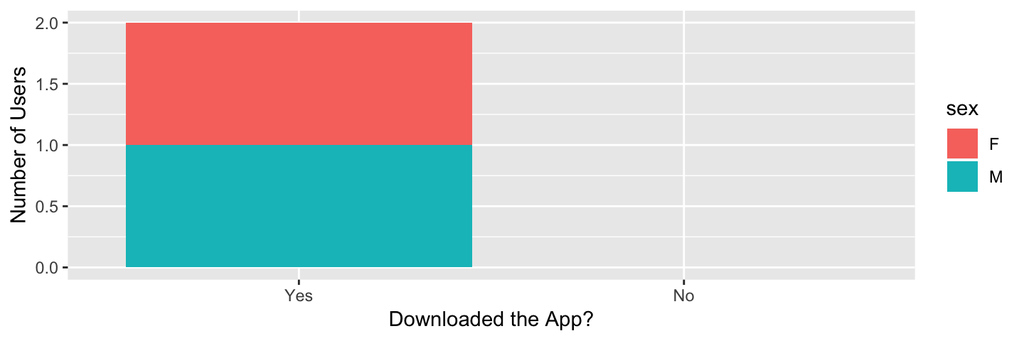

*100% of people who were preteens in 1997 will love this app*

## Introducing: The Titanicly App

**Choose a passenger type! Learn your fate (statistically speaking)! Experience the Titanic with incredible realism!**

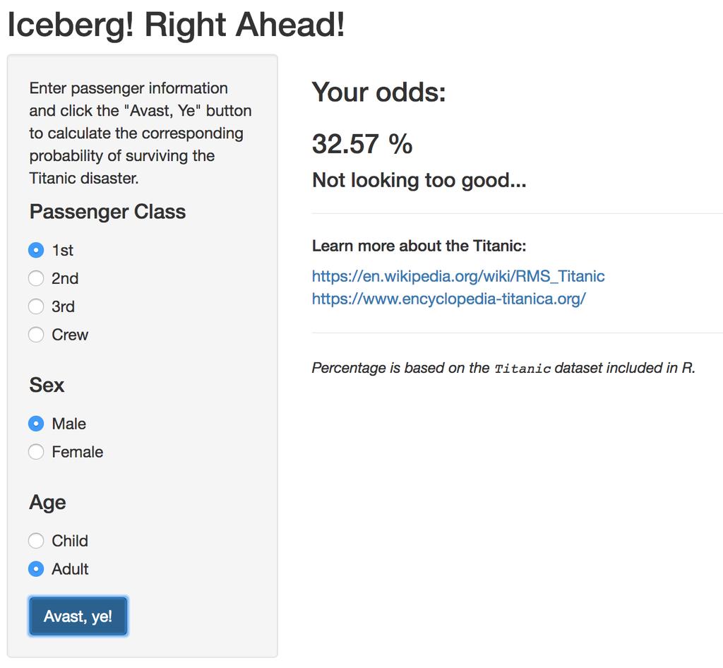

Leverages the incredible `Titanic` dataset built into R:

```r
summary(Titanic)
```

```
## Number of cases in table: 2201
## Number of factors: 4
## Test for independence of all factors:
##  Chisq = 1637.4, df = 25, p-value = 0
##  Chi-squared approximation may be incorrect
```